# solutions 2

Author

JS

```r
library(tidyverse)
library(here)
```

# Easy

## E1: Subset the dataset to include only contain 3 observations per diagnosis. Create a box plot of aortic diameter. Repeat the sub-setting and the plotting. Is the plot changing?

```r
df <- read_tsv(here::here("data/aneurysm_survey/example_data.txt"))
```

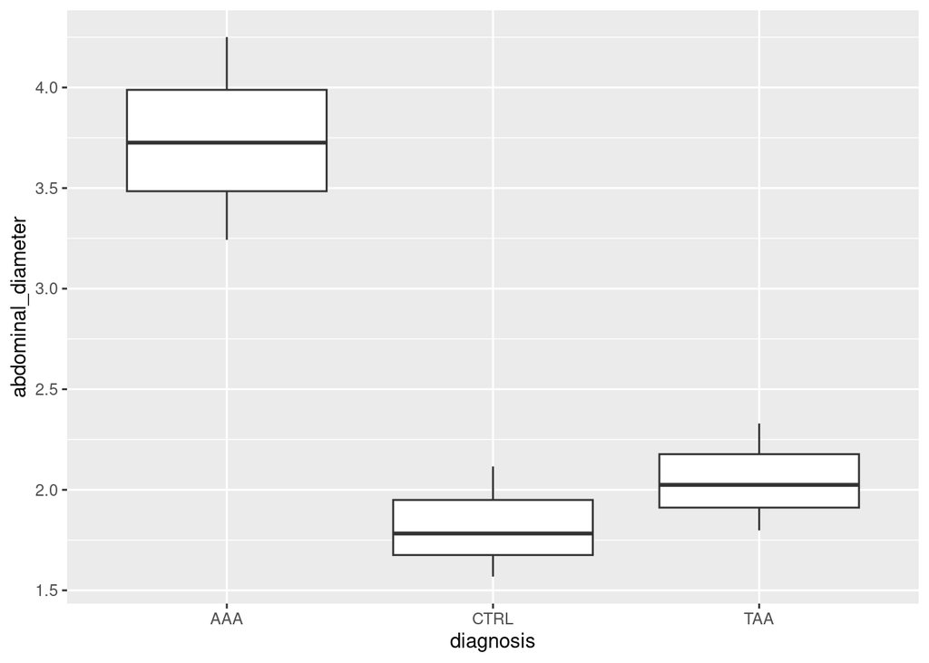

```r
df %>%
  group_by(diagnosis) %>%
  slice_sample(n = 3) %>%
  ungroup() %>%
  ggplot(aes(diagnosis, abdominal_diameter))+
  geom_boxplot()
```

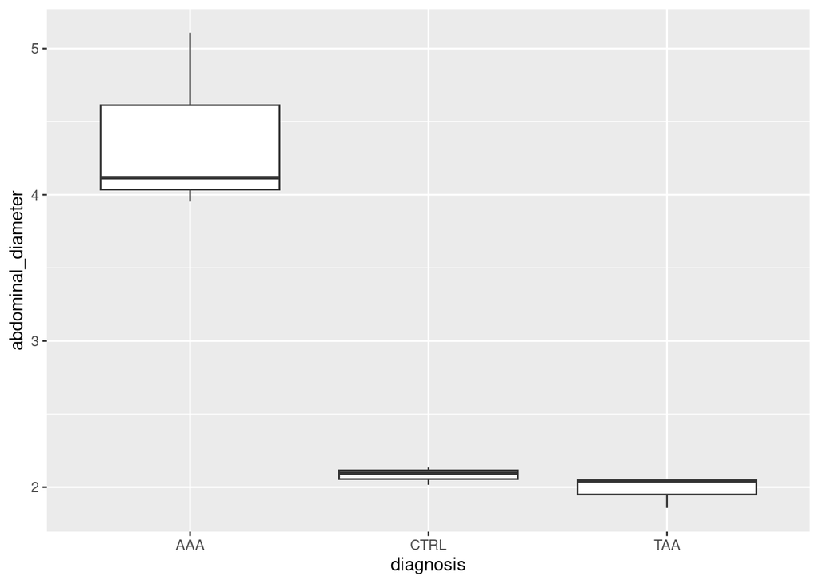

```r
df %>%
  group_by(diagnosis) %>%
  slice_sample(n = 3) %>%
  ungroup() %>%
  ggplot(aes(diagnosis, abdominal_diameter))+
  geom_boxplot()
```

## E2: Repeat this with 10 observations per diagnosis. How stable is the re-sampling then?

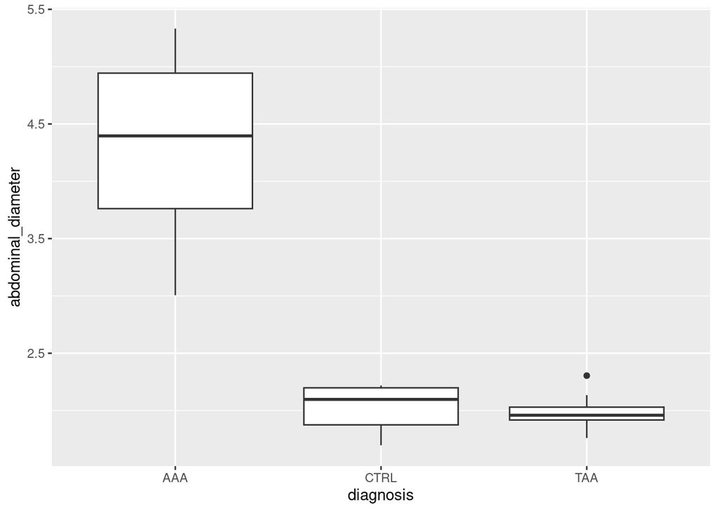

```r
df %>%
  group_by(diagnosis) %>%
  slice_sample(n = 10) %>%
  ungroup() %>%
  ggplot(aes(diagnosis, abdominal_diameter))+
  geom_boxplot()
```

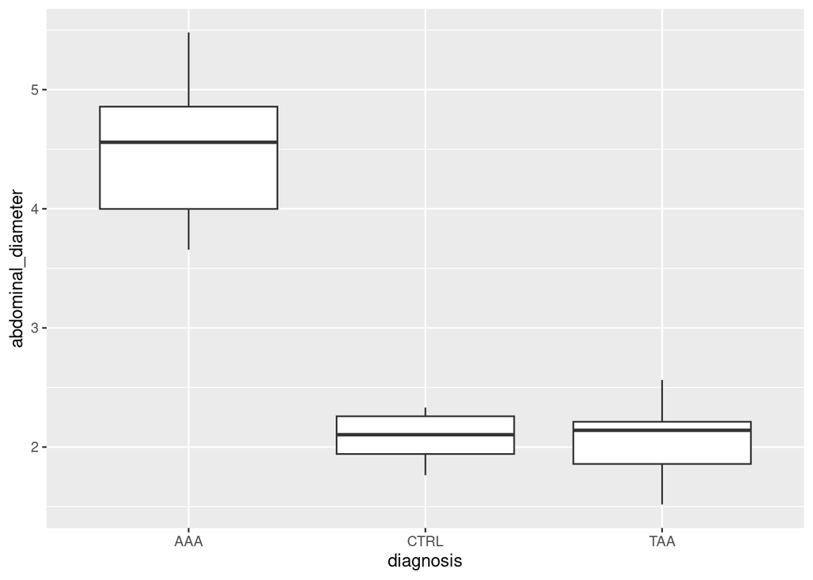

```r
df %>%
  group_by(diagnosis) %>%
  slice_sample(n = 10) %>%
  ungroup() %>%
  ggplot(aes(diagnosis, abdominal_diameter))+
  geom_boxplot()
```

## E3: Lets stick with the 10 observations per observations. Create a boxplot again. Add points on top of it.

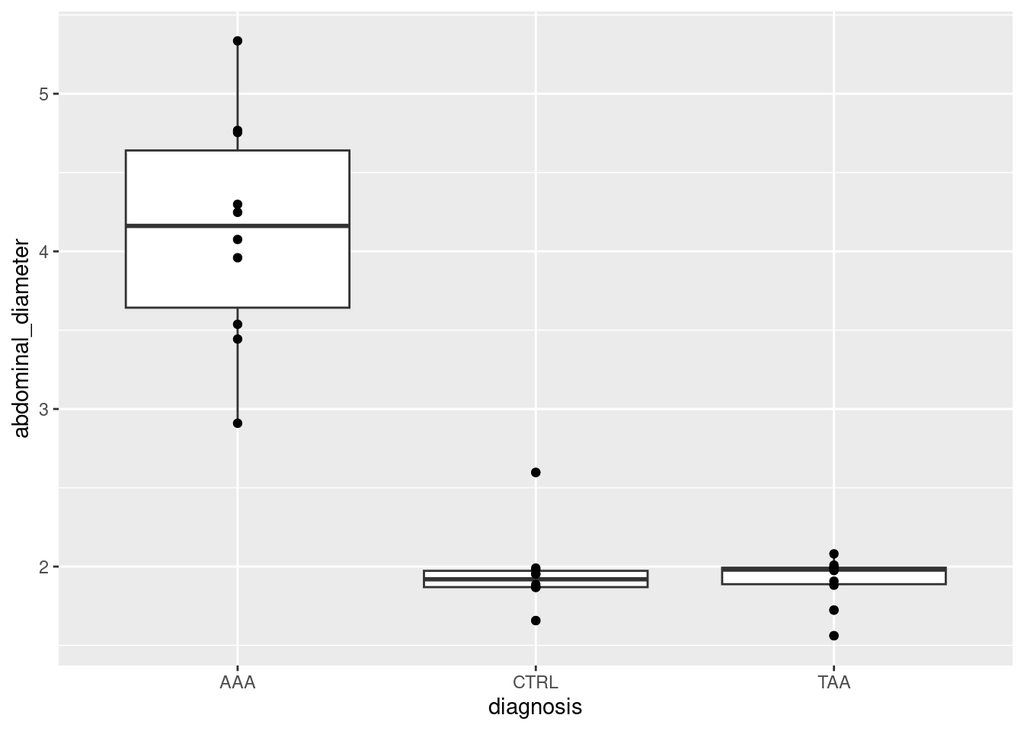

```r
df %>%
  group_by(diagnosis) %>%
  slice_sample(n = 10) %>%
  ungroup() %>%
  ggplot(aes(diagnosis, abdominal_diameter))+
  geom_boxplot()+
  geom_point()
```

## E4: What is the difference between `fill` and `color` for geom_boxplot? Try it out by adding some color to your boxplots.

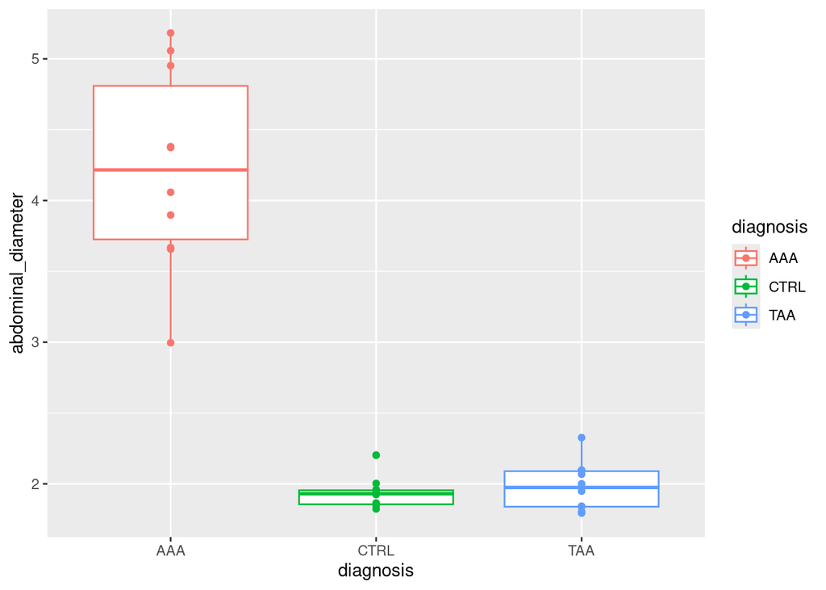

```r
df %>%
  group_by(diagnosis) %>%
  slice_sample(n = 10) %>%
  ungroup() %>%
  ggplot(aes(diagnosis, abdominal_diameter, color = diagnosis))+
  geom_boxplot()+
  geom_point()
```

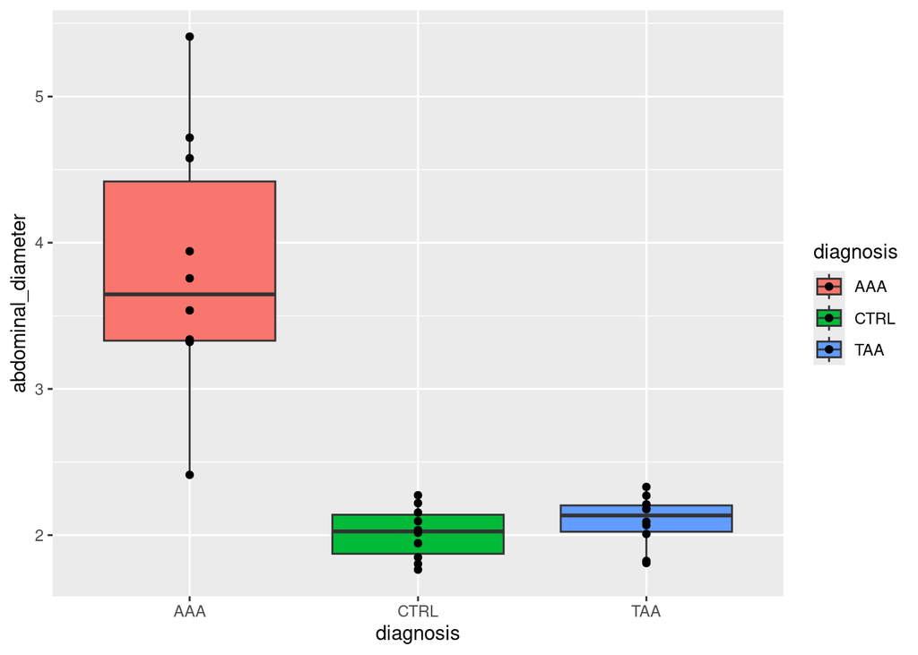

```r
df %>%
  group_by(diagnosis) %>%
  slice_sample(n = 10) %>%
  ungroup() %>%
  ggplot(aes(diagnosis, abdominal_diameter, fill = diagnosis))+
  geom_boxplot()+
  geom_point()
```

## E5: Create a scatter plot using BMI and abdominal aortic diameter. Do you think there is connection?

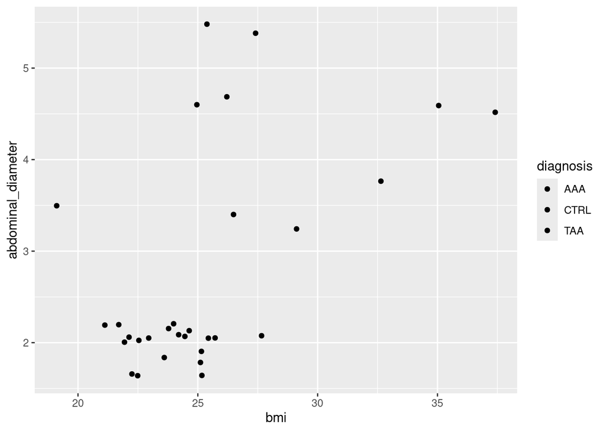

```r
df %>%
  group_by(diagnosis) %>%
  slice_sample(n = 10) %>%
  ungroup() %>%
  ggplot(aes(bmi, abdominal_diameter, fill = diagnosis))+
  geom_point()
```

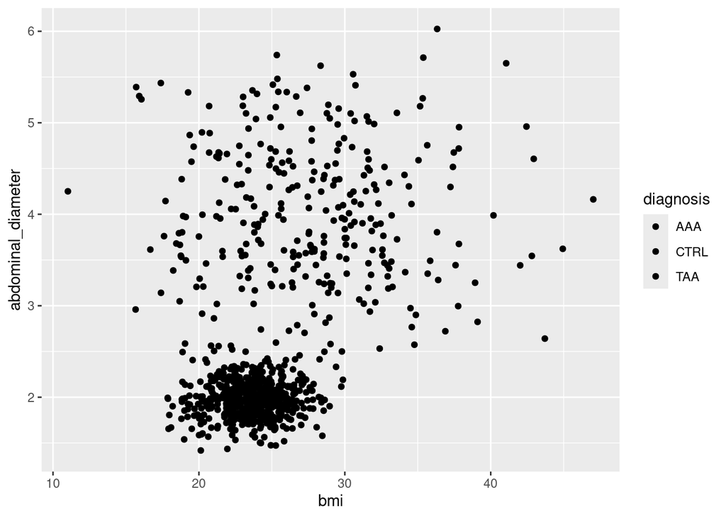

```r
df %>%
  # group_by(diagnosis) %>%
  # slice_sample(n = 10) %>%
  # ungroup() %>%
  ggplot(aes(bmi, abdominal_diameter, fill = diagnosis))+
  geom_point()
```

## E6: Reuse the code for the scatter plot. Set the alpha of the points to 0.5 by using `geom_point(alpha = 0.5)`. What happens? How does the plot change when you change the value?

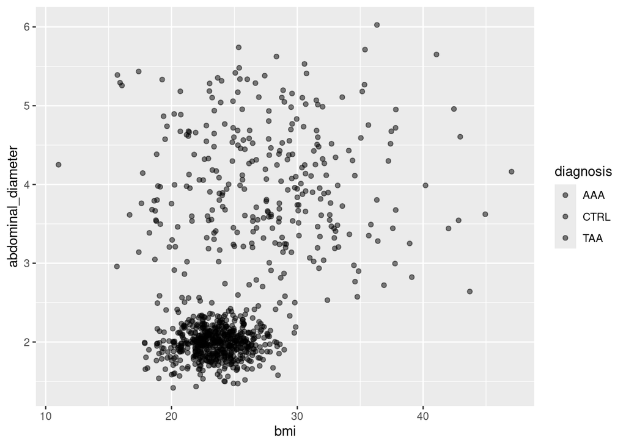

```r
df %>%
  # group_by(diagnosis) %>%
  # slice_sample(n = 10) %>%
  # ungroup() %>%
  ggplot(aes(bmi, abdominal_diameter, fill = diagnosis))+
  geom_point(alpha = 0.5)
```

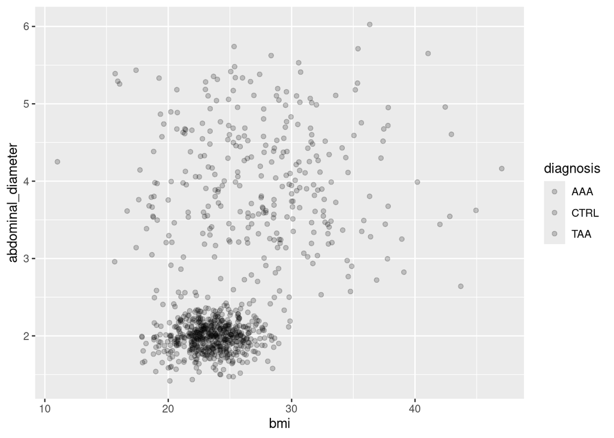

```r
df %>%
  # group_by(diagnosis) %>%
  # slice_sample(n = 10) %>%
  # ungroup() %>%
  ggplot(aes(bmi, abdominal_diameter, fill = diagnosis))+
  geom_point(alpha = 0.2)
```

## E7: Use the same process as above to try some values for the shape of `geom_point()`. The vlaues range from 0 to 25. Which one is a square with a cross in it?

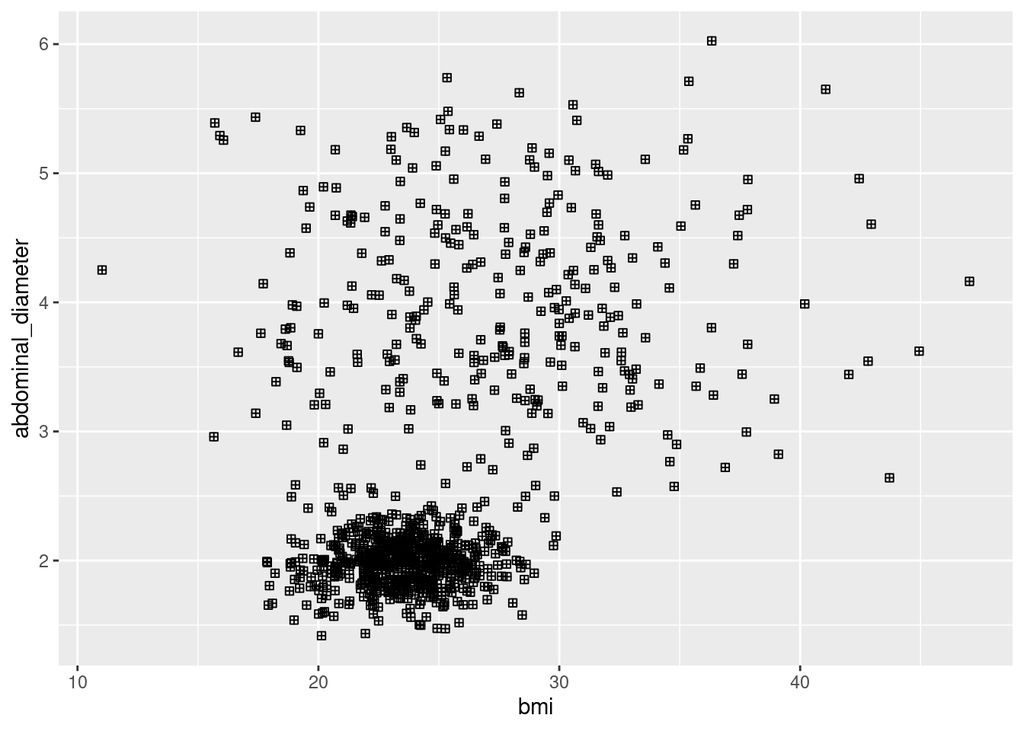

```r
df %>%
  ggplot(aes(bmi, abdominal_diameter))+
  geom_point(shape = 12)
```

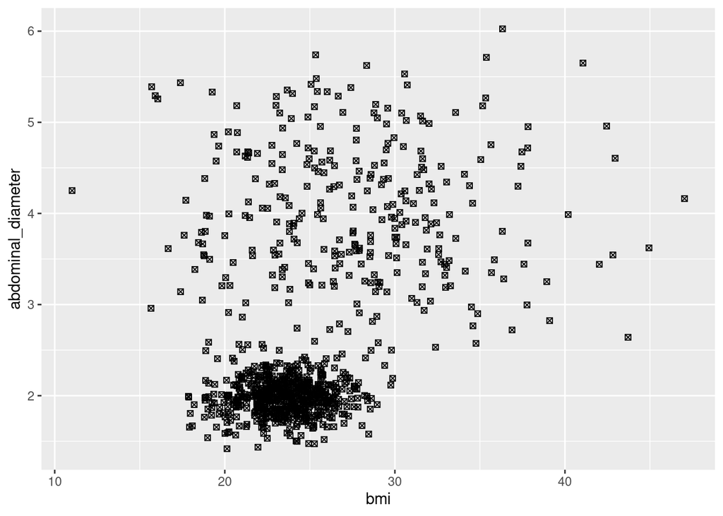

```r
df %>%
  ggplot(aes(bmi, abdominal_diameter))+
  geom_point(shape = 7)
```

## E8: Using `aes()`, set the size of the points to age. What does the plot look like?

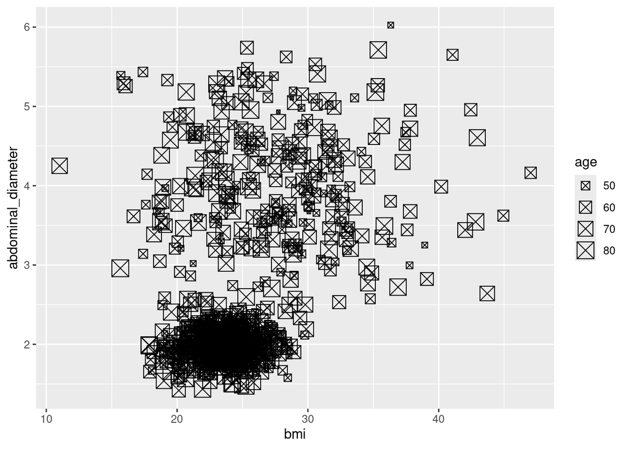

```r
df %>%
  ggplot(aes(bmi, abdominal_diameter, size = age))+
  geom_point(shape = 7)
```

## E9: Try setting the shape of the points by age. What is going wrong?

```r
df %>%
  ggplot(aes(bmi, abdominal_diameter, shape = age))+
  geom_point()
```

```
Error in `geom_point()`:
! Problem while computing aesthetics.
ℹ Error occurred in the 1st layer.
Caused by error in `scale_f()`:
! A continuous variable cannot be mapped to the shape aesthetic.
ℹ Choose a different aesthetic or use `scale_shape_binned()`.
```

## E10: Filter the original data set to patients with a BMI larger than 20. How many patients remain per diagnosis? Plot a bar chart to visualise it.

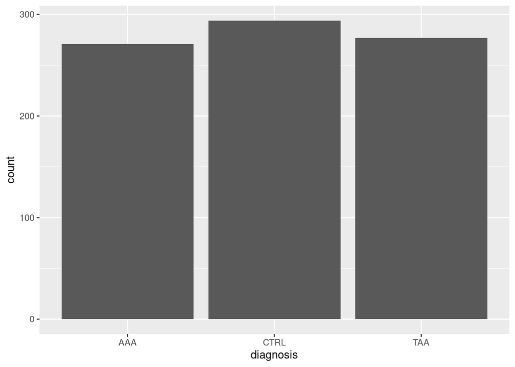

```r
df %>%
  filter(bmi > 20) %>%
  ggplot(aes(diagnosis))+
  geom_bar()
```

# Medium

## M1: Create a box plot of abdominal aortic diameter. Reorder the X axis to have the CTRL diagnosis be the reference level

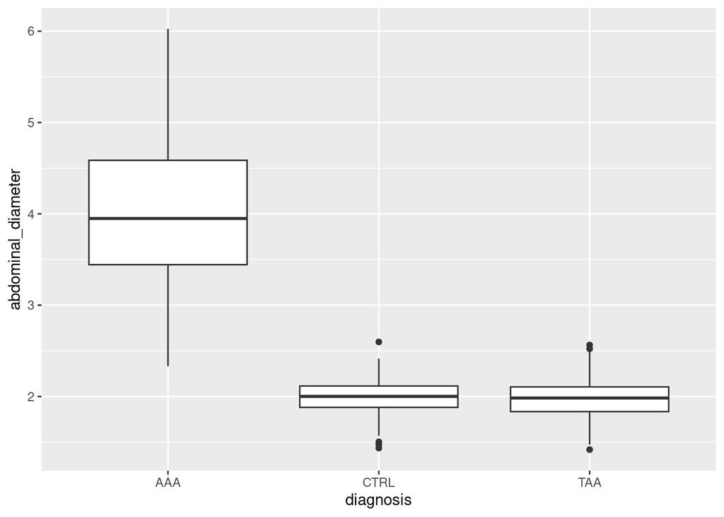

```r
df %>%
  ggplot(aes(diagnosis, abdominal_diameter))+
  geom_boxplot()
```

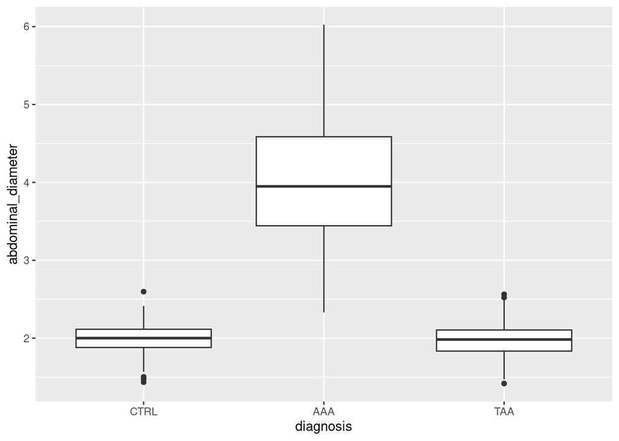

```r
df %>%
  mutate(diagnosis = fct_relevel(diagnosis, "CTRL")) %>%
  ggplot(aes(diagnosis, abdominal_diameter))+
  geom_boxplot()
```

## M2: Recreate the scatter plot from above. Color the points by diagnosis.

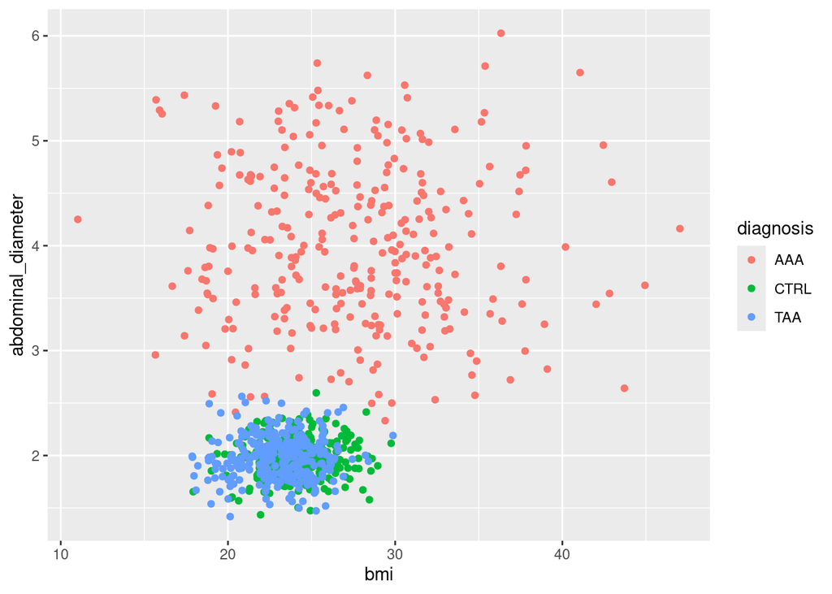

```r
df %>%
  ggplot(aes(bmi, abdominal_diameter, color = diagnosis))+
  geom_point()
```

## M3: Adjust the color code to something of your liking.

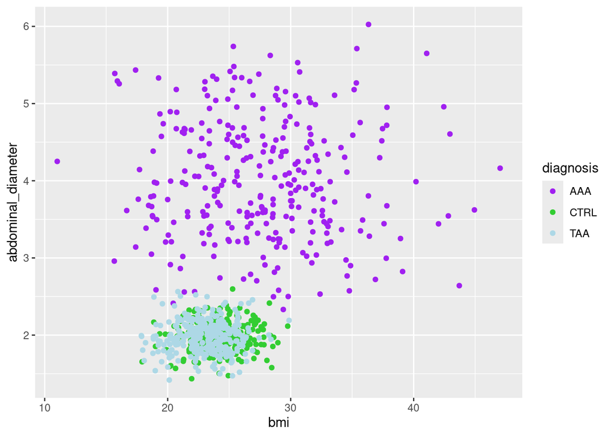

```r
df %>%
  ggplot(aes(bmi, abdominal_diameter, color = diagnosis))+
  geom_point()+
  scale_color_manual(values = c("purple", "limegreen", "lightblue"))
```

## M4: Use geom_histogram() to visualise the distribution of abdominal diameter. Facet using the diagnosis.

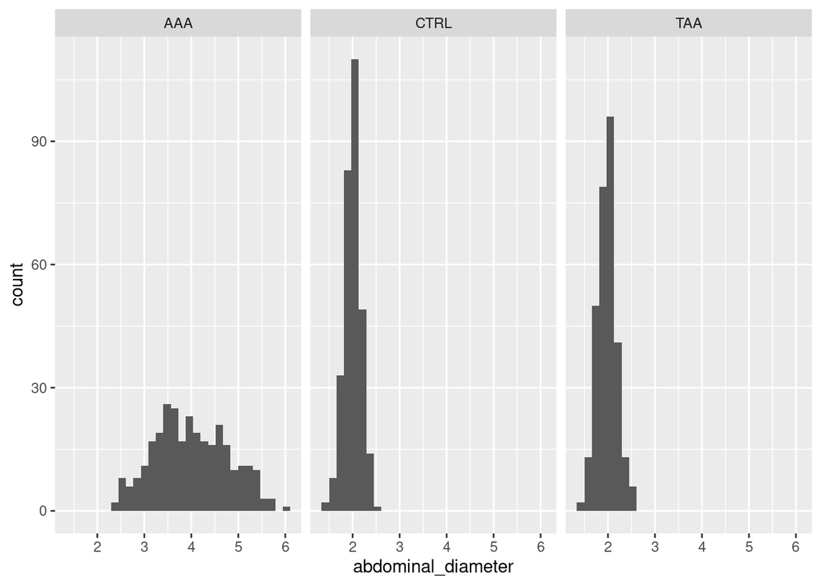

```r
df %>%
  ggplot(aes(abdominal_diameter))+
  geom_histogram()+
  facet_wrap(~diagnosis)
```

```
No summary function supplied, defaulting to `mean_se()`
No summary function supplied, defaulting to `mean_se()`
```

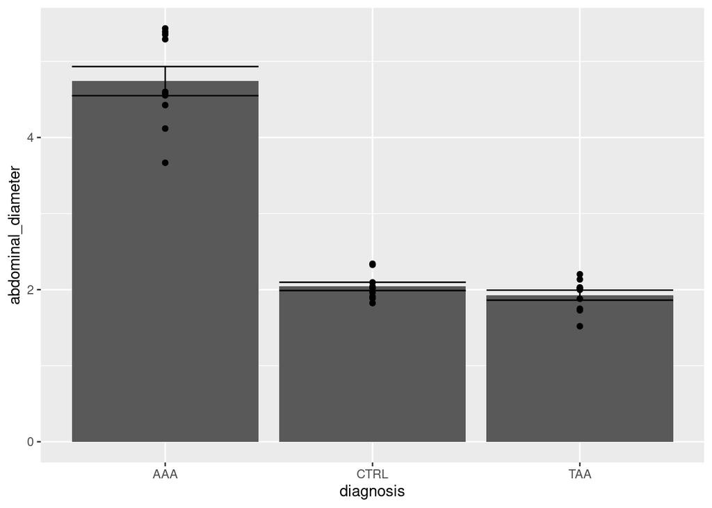

```r
df %>%
  group_by(diagnosis) %>%
  slice_sample(n = 10) %>%
  ungroup() %>%
  ggplot(aes(diagnosis, abdominal_diameter))+
  stat_summary(geom = "bar")+
  stat_summary(geom = "errorbar")+
  geom_point()
```

## M6: Building on the previous task, improve the looks of the previous plot like you would for an important presentation. Adjust Axis labels, fix the order on the x axis, give the plot a title. Color the bars by diagnosis. Try to make it as pleasing as possible (in your eyes).

```
No summary function supplied, defaulting to `mean_se()`
No summary function supplied, defaulting to `mean_se()`
```

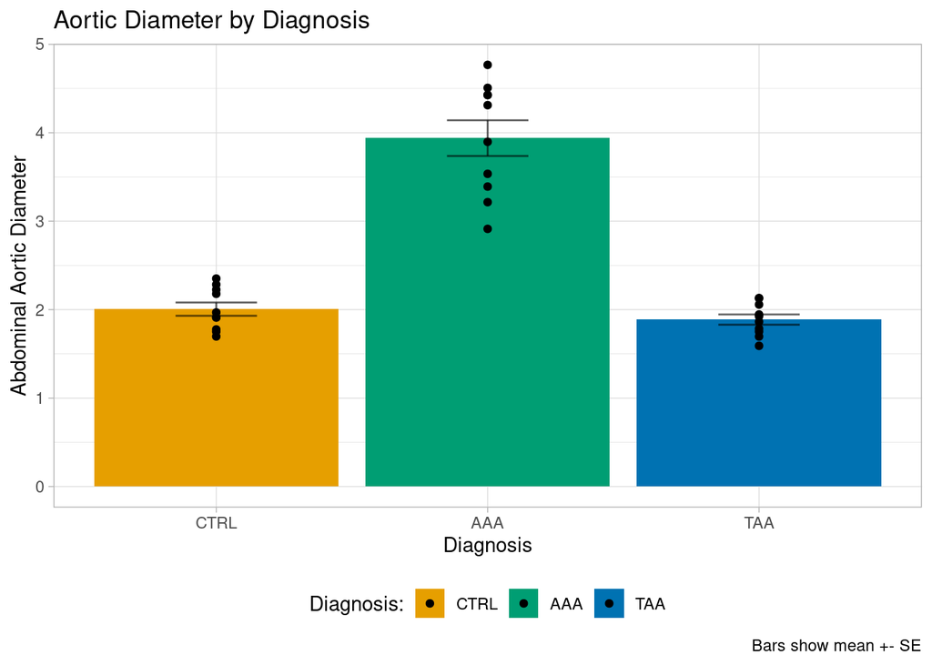

```r
df %>%
  group_by(diagnosis) %>%
  slice_sample(n = 10) %>%
  ungroup() %>%
  mutate(diagnosis = fct_relevel(diagnosis, "CTRL")) %>%
  ggplot(aes(diagnosis, abdominal_diameter, fill = diagnosis))+
  stat_summary(geom = "bar")+
  stat_summary(geom = "errorbar", width = 0.3, alpha = 0.6)+
  geom_point()+
  scale_fill_manual(values = thematic::okabe_ito(n = 3))+
  theme_light()+
  labs(x = "Diagnosis", y = "Abdominal Aortic Diameter",
       title = "Aortic Diameter by Diagnosis",
       caption = "Bars show mean +- SE",
       fill = "Diagnosis:")+
  theme(legend.position = "bottom")
```

## M7: Sample your data to 3 observations per diagnosis. Test the difference in thoracic diameter between the diagnoses. Is the difference significant? Repeat the sampling and test again. Increase the number of observations per diagnosis to 5 and 10. How do the p-values change?

```r
df %>%
  group_by(diagnosis) %>%
  slice_sample(n = 3) %>%
  ungroup() %>%
  rstatix::t_test(thoracic_diameter ~ diagnosis)
```

|  | .y. | group1 | group2 | n1 | n2 | statistic | df | p | p.adj | p.adj.signif |
| --- | --- | --- | --- | --- | --- | --- | --- | --- | --- | --- |
| 1 | thoracic_diameter | AAA | CTRL | 3 | 3 | 2.751573 | 2.331288 | 0.094000 | 0.094 | ns |
| 2 | thoracic_diameter | AAA | TAA | 3 | 3 | -11.531205 | 2.119077 | 0.006000 | 0.012 | * |
| 3 | thoracic_diameter | CTRL | TAA | 3 | 3 | -11.513640 | 3.267318 | 0.000935 | 0.003 | ** |

```r
df %>%
  group_by(diagnosis) %>%
  slice_sample(n = 3) %>%
  ungroup() %>%
  rstatix::t_test(thoracic_diameter ~ diagnosis)
```

|  | .y. | group1 | group2 | n1 | n2 | statistic | df | p | p.adj | p.adj.signif |
| --- | --- | --- | --- | --- | --- | --- | --- | --- | --- | --- |
| 1 | thoracic_diameter | AAA | CTRL | 3 | 3 | 0.5214967 | 2.399548 | 0.646 | 0.646 | ns |
| 2 | thoracic_diameter | AAA | TAA | 3 | 3 | -10.0531463 | 2.083530 | 0.008 | 0.017 | * |
| 3 | thoracic_diameter | CTRL | TAA | 3 | 3 | -9.4721155 | 2.794134 | 0.003 | 0.010 | ** |

```r
df %>%
  group_by(diagnosis) %>%
  slice_sample(n = 3) %>%
  ungroup() %>%
  rstatix::t_test(thoracic_diameter ~ diagnosis)
```

|  | .y. | group1 | group2 | n1 | n2 | statistic | df | p | p.adj | p.adj.signif |
| --- | --- | --- | --- | --- | --- | --- | --- | --- | --- | --- |
| 1 | thoracic_diameter | AAA | CTRL | 3 | 3 | -5.673997 | 3.763952 | 0.006 | 0.017 | * |
| 2 | thoracic_diameter | AAA | TAA | 3 | 3 | -10.560884 | 2.181780 | 0.007 | 0.017 | * |
| 3 | thoracic_diameter | CTRL | TAA | 3 | 3 | -9.143385 | 2.109114 | 0.010 | 0.017 | * |

```r
df %>%
  group_by(diagnosis) %>%
  slice_sample(n = 5) %>%
  ungroup() %>%
  rstatix::t_test(thoracic_diameter ~ diagnosis)
```

|  | .y. | group1 | group2 | n1 | n2 | statistic | df | p | p.adj | p.adj.signif |
| --- | --- | --- | --- | --- | --- | --- | --- | --- | --- | --- |
| 1 | thoracic_diameter | AAA | CTRL | 5 | 5 | -0.21063 | 7.998854 | 8.38e-01 | 0.83800 | ns |
| 2 | thoracic_diameter | AAA | TAA | 5 | 5 | -10.77251 | 5.270638 | 8.67e-05 | 0.00026 | *** |
| 3 | thoracic_diameter | CTRL | TAA | 5 | 5 | -10.67936 | 5.242087 | 9.37e-05 | 0.00026 | *** |

```r
df %>%
  group_by(diagnosis) %>%
  slice_sample(n = 5) %>%
  ungroup() %>%
  rstatix::t_test(thoracic_diameter ~ diagnosis)
```

|  | .y. | group1 | group2 | n1 | n2 | statistic | df | p | p.adj | p.adj.signif |
| --- | --- | --- | --- | --- | --- | --- | --- | --- | --- | --- |
| 1 | thoracic_diameter | AAA | CTRL | 5 | 5 | 0.1554073 | 6.419657 | 8.81e-01 | 8.81e-01 | ns |
| 2 | thoracic_diameter | AAA | TAA | 5 | 5 | -16.9984519 | 5.861110 | 3.28e-06 | 6.56e-06 | **** |
| 3 | thoracic_diameter | CTRL | TAA | 5 | 5 | -14.5354356 | 7.814352 | 6.18e-07 | 1.85e-06 | **** |

```r
df %>%
  group_by(diagnosis) %>%
  slice_sample(n = 10) %>%
  ungroup() %>%
  rstatix::t_test(thoracic_diameter ~ diagnosis)
```

|  | .y. | group1 | group2 | n1 | n2 | statistic | df | p | p.adj | p.adj.signif |
| --- | --- | --- | --- | --- | --- | --- | --- | --- | --- | --- |
| 1 | thoracic_diameter | AAA | CTRL | 10 | 10 | 0.9043508 | 11.41950 | 3.84e-01 | 3.84e-01 | ns |
| 2 | thoracic_diameter | AAA | TAA | 10 | 10 | -20.9003619 | 11.58592 | 1.47e-10 | 2.94e-10 | **** |
| 3 | thoracic_diameter | CTRL | TAA | 10 | 10 | -16.2433642 | 17.97846 | 3.45e-12 | 1.04e-11 | **** |

```r
df %>%
  group_by(diagnosis) %>%
  slice_sample(n = 10) %>%
  ungroup() %>%
  rstatix::t_test(thoracic_diameter ~ diagnosis)
```

|  | .y. | group1 | group2 | n1 | n2 | statistic | df | p | p.adj | p.adj.signif |
| --- | --- | --- | --- | --- | --- | --- | --- | --- | --- | --- |
| 1 | thoracic_diameter | AAA | CTRL | 10 | 10 | 1.775993 | 12.85720 | 9.90e-02 | 9.90e-02 | ns |
| 2 | thoracic_diameter | AAA | TAA | 10 | 10 | -20.163176 | 11.50125 | 2.47e-10 | 4.94e-10 | **** |
| 3 | thoracic_diameter | CTRL | TAA | 10 | 10 | -18.099325 | 17.11562 | 1.35e-12 | 4.05e-12 | **** |

# Hard

## H1: What happens when you run the following code?

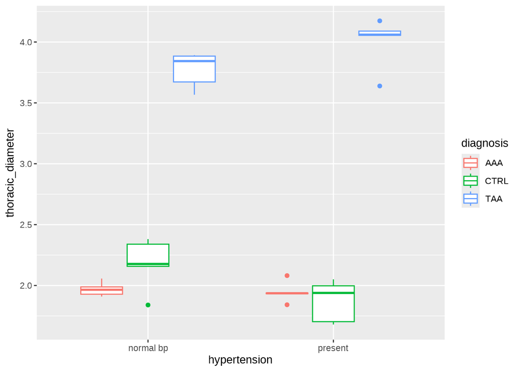

```r
df <- read_tsv(here("data", "aneurysm_survey", "example_data.txt"))
df_plot <- df %>%
  group_by(diagnosis, hypertension) %>%
  slice_sample(n = 5) %>%
  ungroup() %>%
  mutate(hypertension = ifelse(hypertension, "present", "normal bp"))

df_plot  %>%
  ggplot(aes(hypertension, thoracic_diameter, color = diagnosis))+
  geom_boxplot()
```

## H2: Try adding points to the plot using `geom_point()`. What happens? Can you fix their position? Hint: look at the `position` argument of `geom_point()`.

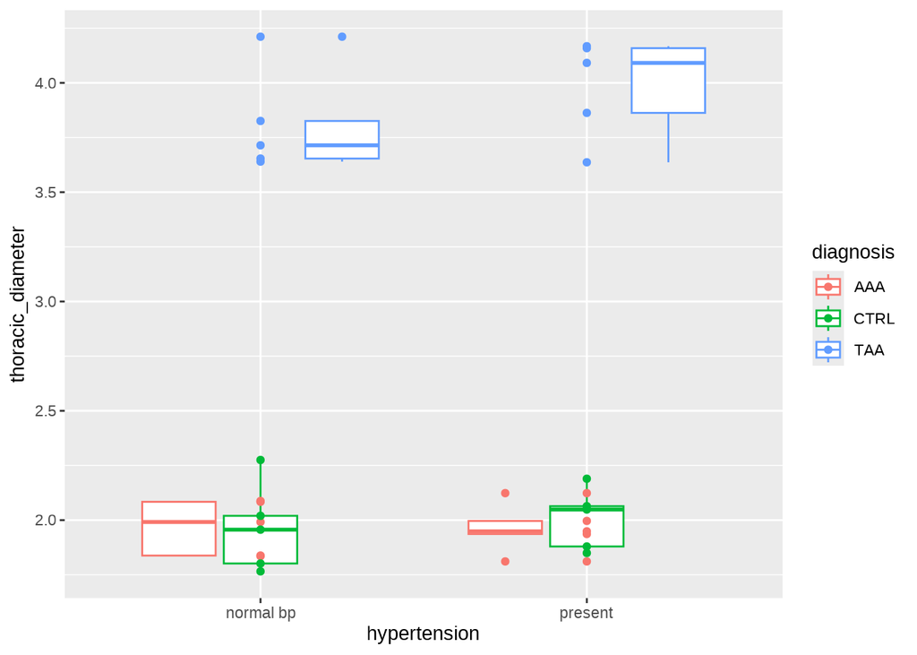

```r
df_plot <- df %>%
  group_by(diagnosis, hypertension) %>%
  slice_sample(n = 5) %>%
  ungroup() %>%
  mutate(hypertension = ifelse(hypertension, "present", "normal bp"))

df_plot  %>%
  ggplot(aes(hypertension, thoracic_diameter, color = diagnosis))+
  geom_boxplot()+
  geom_point()
```

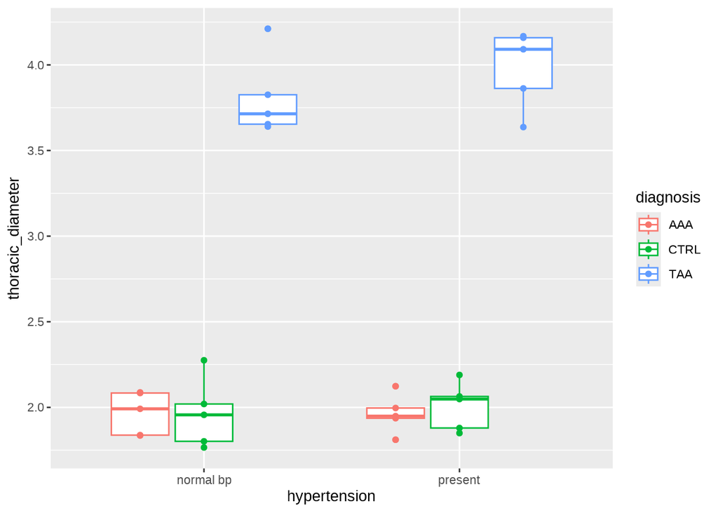

```r
df_plot  %>%
  ggplot(aes(hypertension, thoracic_diameter, color = diagnosis))+
  geom_boxplot()+
  geom_point(position = position_dodge(width  = 0.75))
```

## H3: Using what we learned last session, build an expression plot of *IL6* using the airway data. Best use `geom_boxplot()` and `geom_point()`.

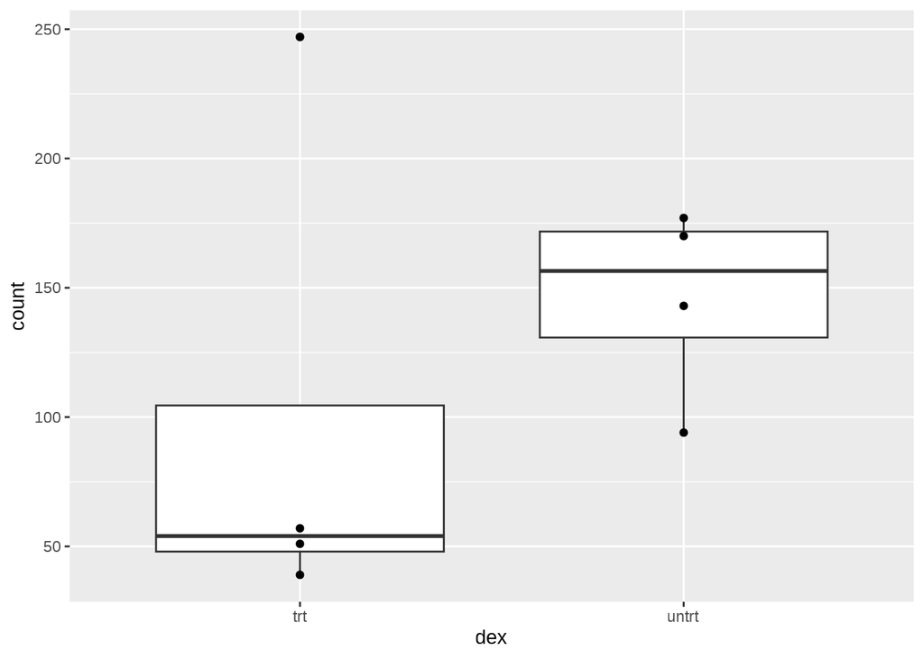

```r
counts <- read_tsv(here::here("data/expression_data/counts.txt"))
annotation <- read_tsv(here::here("data/expression_data/annotation.txt"))
counts_long <- counts %>% pivot_longer( # take the data and pivot longer
  cols = -gene, # select the columns to pivot longer, here everything but the gene column (similar to select)
  names_to = "sample", # put the column names into a new column called sample
  values_to = "count") # put the corresponding values ion a new column called count )

anno_filtered <- annotation %>% select(Run, dex, cell)

df_long <- counts_long %>% inner_join(anno_filtered, # join in the filtered annotation
                                      by = join_by(sample == Run))

df_long %>%
  filter(gene == "IL6") %>%
  ggplot(aes(dex, count))+
  geom_boxplot()+
  geom_point()
```

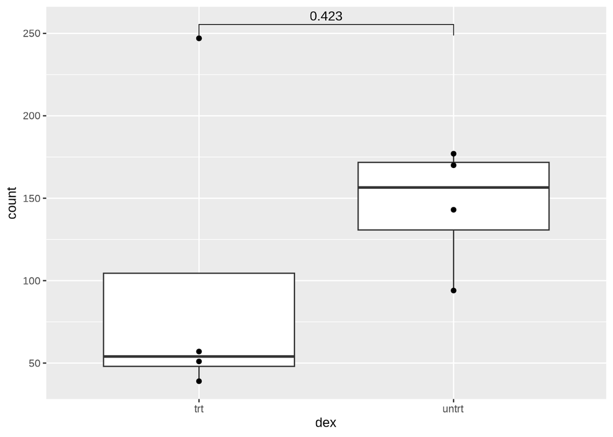

```r
stats <- df_long %>%
  filter(gene == "IL6") %>%
  rstatix::t_test(count ~ dex) %>%
  rstatix::add_xy_position()

df_long %>%
  filter(gene == "IL6") %>%
  ggplot(aes(dex, count))+
  geom_boxplot()+
  geom_point()+
  ggpubr::stat_pvalue_manual(stats)
```